# ACLU Jail Release Inquiry

Charlotte McClintock

February 2019

# Inquiry

Request from ACLU:

> So, we have been hearing reports that Denver takes FOREVER to release people after they have posted bond. We had found a few anecdotal examples of people who got PR bonds but it took them 23-24 hours to be released. El Paso County, in contrast, says that they release people on average within about 2 hours of posting bond. Alarmed, we asked Denver for stats on their release times after someone has posted bond. In a meeting the city attorney told us that on average takes them 6 hours to release someone (that’s still pretty bad). We asked for the underlying data. I have waited about 3 months for the data, which they finally sent over today. As I understand it, Column L is the date when the bond was paid/posted (which starts the clock of when they need to release the person). Column U is the data and time when they were released one of Denver’s two jails (either DJC or COJL). The goal here is to get the difference between these two dates and times. I hope to calculate our own average to see if it lines us with the 6 hours that they reported to us—it would also be great to get average release times for each “reason description” listed (Column T). For example, I see some 100+ day waits for releases to DOC which makes sense because DOC is backlogged. But, I am very concerned about some that I see that are 16 day waits when the person is just released to pretrial services locally—that makes NO sense and is outrageous.

# Methodology

I separated the date time variables and reunited them to coerce them to POSIX format, then calculated the time difference in hours.

```r
# clean names
names(jail) <- str_to_lower(names(jail))

# bail posted date and time
jail <- separate(jail, `createdatetime from obp`, into = c("day", "month", "year"), sep="-")
jail <- separate(jail, year, into = c("year", "time", "ampm"), sep=" ", extra = "merge")
jail <- separate(jail, time, into = c("hour", "minute", "second"), sep="\\.", extra = "drop")
jail$cent <- "20"
jail <- unite(jail, "time", hour, minute, second, sep=":")
jail <- unite(jail, "year", cent, year, sep="")
jail <- unite(jail, "date", year, month, day, sep='-')
jail$date <- strptime(jail$date,format="%Y-%b-%d")
jail <- unite(jail, "bailposteddate", date, time, ampm, sep=" ")
jail$bailposteddate <-  ymd_hms(jail$bailposteddate)

# release date and time
jail <- separate(jail, `maxmove_datetime`, into = c("day", "month", "year"), sep="-")
jail <- separate(jail, year, into = c("year", "time", "ampm"), sep=" ", extra = "merge")
jail <- separate(jail, time, into = c("hour", "minute", "second"), sep="\\.", extra = "drop")
jail$cent <- "20"
jail <- unite(jail, "time", hour, minute, second, sep=":")
jail <- unite(jail, "year", cent, year, sep="")
jail <- unite(jail, "date", year, month, day, sep='-')
jail$date <- strptime(jail$date,format="%Y-%b-%d")
jail <- unite(jail, "releasedate", date, time, ampm, sep=" ")
jail$releasedate <-  ymd_hms(jail$releasedate)

# calculate time to release
jail$releasediff <- with(jail, difftime(releasedate, bailposteddate, units="hours"))

# select relevant variables
jail <- select(jail, cd, bailposteddate, releasedate, releasediff, race, gender,
               `movement reason description`, `release agency`, los)

# remove duplicate observations
jail <- unique(jail)
```

```r
jail.neg <- subset(jail, releasediff<0) %>% select(-c(cd, race, gender, `release agency`))
kable(jail.neg)
```

| bailposteddate | releasedate | releasediff | movement reason description | los |
| --- | --- | --- | --- | --- |
| 2018-01-16 09:53:33 | 2018-01-15 20:58:09 | -12.923333 hours | RELEASED - BONDED NO CRT ORDERED REST | 2 |
| 2018-02-10 19:14:12 | 2018-02-10 19:08:03 | -0.102500 hours | RELEASED - PR BOND GRANTED | 1 |
| 2018-04-18 14:11:35 | 2018-04-17 18:52:31 | -19.317778 hours | RELEASED - PRE-TRIAL SERVICES | 2 |
| 2018-05-15 02:55:50 | 2017-06-15 07:04:34 | -8011.854444 hours | RELEASED - OTHER | 479 |
| 2018-06-27 14:25:52 | 2018-06-26 23:55:31 | -14.505833 hours | RELEASED - BONDED NO CRT ORDERED REST | 7 |
| 2018-09-17 11:25:25 | 2018-09-08 09:27:31 | -217.965000 hours | RELEASED - PRE-TRIAL SERVICES | 12 |
| 2018-09-19 18:50:51 | 2018-09-08 09:27:31 | -273.388889 hours | RELEASED - PRE-TRIAL SERVICES | 12 |
| 2018-09-24 01:25:49 | 2018-09-24 01:24:37 | -0.020000 hours | RELEASED - BONDED NO CRT ORDERED REST | 3 |
| 2018-10-31 10:56:24 | 2018-10-30 10:27:16 | -24.485556 hours | RELEASED - OTHER JURISDICTION | 1 |
| 2018-11-16 10:05:38 | 2018-10-17 15:41:46 | -714.397778 hours | RELEASED - PRE-TRIAL SERVICES | 31 |
| 2018-12-09 15:48:31 | 2018-12-09 13:31:49 | -2.278333 hours | RELEASED - PR BOND GRANTED | 2 |
| 2018-12-24 15:58:36 | 2018-12-24 11:32:58 | -4.427222 hours | RELEASED - PR BOND GRANTED | 2 |

Subset the data to specifically focus on release on bond, down to 25331 observations from 29469.

```r
# rename a variable for ease of use.
jail <- rename(jail, "mvmtreason"="movement reason description")
# drop anomalous reasons for release, keep bonds
jail.bond <- subset(jail, mvmtreason=="RELEASED - PR BOND GRANTED"|
                      mvmtreason=="RELEASED - PRE-TRIAL SERVICES"|
                      mvmtreason=="RELEASED - BONDED NO CRT ORDERED REST")
```

How is this distributed? Strongly right skewed, with a high number of lower values.

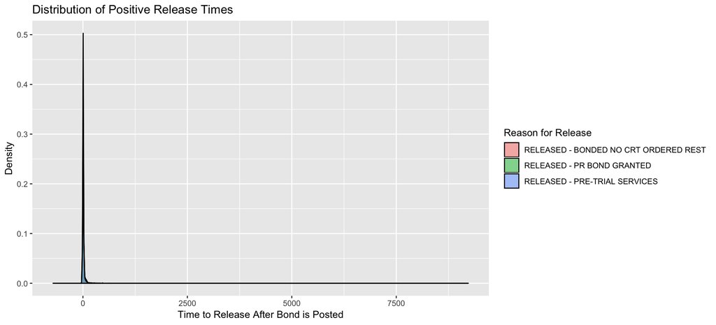

```r
ggplot(jail.bond, aes(releasediff, fill=mvmtreason)) +
  geom_density(alpha=0.5) +
  labs(title="Distribution of Positive Release Times",
       x="Time to Release After Bond is Posted",
       y="Density",
       fill="Reason for Release")
```

Means for each reason are much higher than medians, pulled up by extreme values.

```r
kable(jail.bond %>% group_by(mvmtreason) %>% summarise(mean=mean(releasediff),
                                                 median=median(releasediff)))
```

| mvmtreason | mean | median |
| --- | --- | --- |
| RELEASED - BONDED NO CRT ORDERED REST | 17.14821 hours | 3.748889 hours |
| RELEASED - PR BOND GRANTED | 15.41732 hours | 4.136250 hours |
| RELEASED - PRE-TRIAL SERVICES | 37.63761 hours | 5.118472 hours |

```r
jail.high <- subset(jail.bond, releasediff>=24)
nrow(jail.high)
```

```
## [1] 2572
```

Do the high release times come from one reason in particular? No, significant numbers in each.

```r
jail.high %>% group_by(mvmtreason) %>% count() %>% kable()
```

| mvmtreason | n |
| --- | --- |
| RELEASED - BONDED NO CRT ORDERED REST | 859 |
| RELEASED - PR BOND GRANTED | 453 |
| RELEASED - PRE-TRIAL SERVICES | 1260 |

What does the distribution look like if we remove release times over 48 hours?

```r
jail.bond.small <- subset(jail.bond, releasediff>0&releasediff<=48)

# define modal function
getmode <- function(v) {
  uniqv <- unique(v)
  uniqv[which.max(tabulate(match(v, uniqv)))]
}

# central tendency measures
mean(jail.bond.small$releasediff)
```

```
## Time difference of 6.687064 hours
```

```r
median(jail.bond.small$releasediff)
```

```
## Time difference of 3.9725 hours
```

```r
getmode(jail.bond.small$releasediff)
```

```
## [1] 1.932778
```

[figure not shown]

```r
ggplot(jail.bond.small, aes(releasediff, fill=mvmtreason)) +
  geom_density(alpha=0.5) +
  theme(legend.position = "right") +
  geom_vline(xintercept=1.93, linetype=3) +
  geom_vline(xintercept=6.68, linetype=3) +
  geom_vline(xintercept=3.925, linetype=3) +
  annotate("text", x=1, y=0.025, label="mode: 1.93", angle=90) +
  annotate("text", x=6, y=0.15, label="mean: 6.68", angle=90) +
  annotate("text", x=3, y=0.05, label="median: 3.92", angle=90) +
  labs(title="Distribution of Release Times Under 48 Hours",
       x="Time to Release After Bond is Posted",
       y="Density",
       fill="Reason for Release")
```

```r
kable(jail.bond.small %>% group_by(mvmtreason) %>% summarise(mean=mean(releasediff),
                                                 median=median(releasediff)))
```

| mvmtreason | mean | median |
| --- | --- | --- |
| RELEASED - BONDED NO CRT ORDERED REST | 5.942916 hours | 3.527778 hours |
| RELEASED - PR BOND GRANTED | 6.180585 hours | 3.904722 hours |
| RELEASED - PRE-TRIAL SERVICES | 7.814079 hours | 4.585972 hours |

Are there differences by race or gender?

```r
kable(jail.bond %>% group_by(gender) %>% summarise(mean=mean(releasediff),
                                                 median=median(releasediff)))
```

| gender | mean | median |
| --- | --- | --- |
| Female | 20.82874 hours | 3.835833 hours |
| Male | 25.72354 hours | 4.447778 hours |

```r
kable(jail.bond %>% group_by(race) %>% summarise(mean=mean(releasediff),
                                                 median=median(releasediff)))
```

| race | mean | median |
| --- | --- | --- |
| American Indian, Alaskan Native | 14.928169 hours | 4.521806 hours |
| Asian / Pacific Islander | 20.198881 hours | 3.765694 hours |
| Black | 29.117547 hours | 4.300000 hours |
| Hispanic | 23.599635 hours | 4.305000 hours |
| Unknown | 32.206358 hours | 4.210000 hours |
| White | 22.449888 hours | 4.258056 hours |
| NA | 6.109074 hours | 2.465000 hours |

Does release time depend on length of stay? (assuming here that los means length of stay)

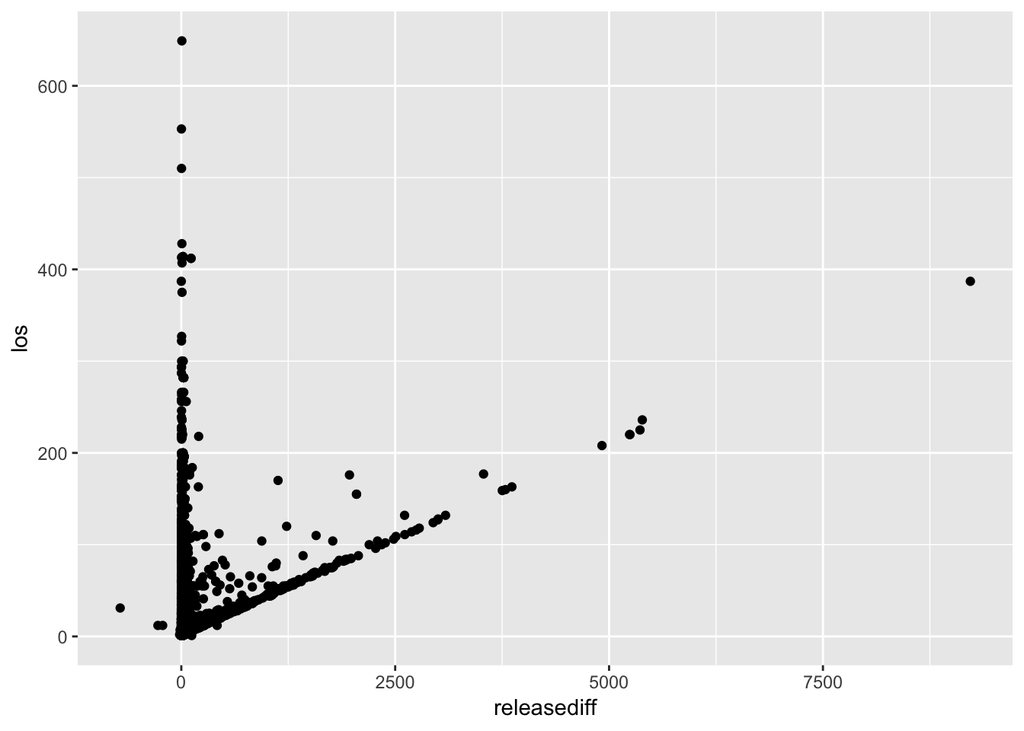

```r
ggplot(jail.bond, aes(releasediff, los)) + geom_point()
```